# Risk Factor Analysis

## Outcome Variable

**Outcome Variable:** ever_swasted

## Predictor Variables

**Intervention Variable:** mage

**Adjustment Set:**

- arm
- meducyrs
- feducyrs
- W_mhtcm
- W_mwtkg
- W_mbmi
- single
- delta_meducyrs
- delta_feducyrs
- delta_W_mhtcm
- delta_W_mwtkg
- delta_W_mbmi
- delta_single

## Stratifying Variables

The analysis was stratified on these variable(s):

- agecat
- studyid
- country

## Data Summary

| agecat | studyid | country | mage | ever_swasted | n_cell | n |
| --- | --- | --- | --- | --- | --- | --- |
| 0-24 months | ki0047075b-MAL-ED | BANGLADESH | [20-30) | 0 | 167 | 263 |
| 0-24 months | ki0047075b-MAL-ED | BANGLADESH | [20-30) | 1 | 13 | 263 |
| 0-24 months | ki0047075b-MAL-ED | BANGLADESH | <20 | 0 | 32 | 263 |
| 0-24 months | ki0047075b-MAL-ED | BANGLADESH | <20 | 1 | 5 | 263 |
| 0-24 months | ki0047075b-MAL-ED | BANGLADESH | >=30 | 0 | 43 | 263 |
| 0-24 months | ki0047075b-MAL-ED | BANGLADESH | >=30 | 1 | 3 | 263 |
| 0-24 months | ki0047075b-MAL-ED | BRAZIL | [20-30) | 0 | 138 | 233 |
| 0-24 months | ki0047075b-MAL-ED | BRAZIL | [20-30) | 1 | 1 | 233 |
| 0-24 months | ki0047075b-MAL-ED | BRAZIL | <20 | 0 | 41 | 233 |
| 0-24 months | ki0047075b-MAL-ED | BRAZIL | <20 | 1 | 2 | 233 |
| 0-24 months | ki0047075b-MAL-ED | BRAZIL | >=30 | 0 | 50 | 233 |
| 0-24 months | ki0047075b-MAL-ED | BRAZIL | >=30 | 1 | 1 | 233 |
| 0-24 months | ki0047075b-MAL-ED | INDIA | [20-30) | 0 | 172 | 249 |
| 0-24 months | ki0047075b-MAL-ED | INDIA | [20-30) | 1 | 22 | 249 |
| 0-24 months | ki0047075b-MAL-ED | INDIA | <20 | 0 | 31 | 249 |
| 0-24 months | ki0047075b-MAL-ED | INDIA | <20 | 1 | 3 | 249 |
| 0-24 months | ki0047075b-MAL-ED | INDIA | >=30 | 0 | 20 | 249 |
| 0-24 months | ki0047075b-MAL-ED | INDIA | >=30 | 1 | 1 | 249 |
| 0-24 months | ki0047075b-MAL-ED | NEPAL | [20-30) | 0 | 180 | 240 |
| 0-24 months | ki0047075b-MAL-ED | NEPAL | [20-30) | 1 | 9 | 240 |
| 0-24 months | ki0047075b-MAL-ED | NEPAL | <20 | 0 | 5 | 240 |
| 0-24 months | ki0047075b-MAL-ED | NEPAL | <20 | 1 | 0 | 240 |
| 0-24 months | ki0047075b-MAL-ED | NEPAL | >=30 | 0 | 46 | 240 |
| 0-24 months | ki0047075b-MAL-ED | NEPAL | >=30 | 1 | 0 | 240 |
| 0-24 months | ki0047075b-MAL-ED | PERU | [20-30) | 0 | 150 | 302 |
| 0-24 months | ki0047075b-MAL-ED | PERU | [20-30) | 1 | 3 | 302 |
| 0-24 months | ki0047075b-MAL-ED | PERU | <20 | 0 | 81 | 302 |
| 0-24 months | ki0047075b-MAL-ED | PERU | <20 | 1 | 1 | 302 |
| 0-24 months | ki0047075b-MAL-ED | PERU | >=30 | 0 | 67 | 302 |
| 0-24 months | ki0047075b-MAL-ED | PERU | >=30 | 1 | 0 | 302 |

[output cut: 450 more lines]

The following strata were considered:

- agecat: 0-24 months, studyid: ki0047075b-MAL-ED, country: BANGLADESH
- agecat: 0-24 months, studyid: ki0047075b-MAL-ED, country: BRAZIL
- agecat: 0-24 months, studyid: ki0047075b-MAL-ED, country: INDIA
- agecat: 0-24 months, studyid: ki0047075b-MAL-ED, country: NEPAL
- agecat: 0-24 months, studyid: ki0047075b-MAL-ED, country: PERU
- agecat: 0-24 months, studyid: ki0047075b-MAL-ED, country: SOUTH AFRICA
- agecat: 0-24 months, studyid: ki0047075b-MAL-ED, country: TANZANIA, UNITED REPUBLIC OF
- agecat: 0-24 months, studyid: ki1000108-CMC-V-BCS-2002, country: INDIA
- agecat: 0-24 months, studyid: ki1000108-IRC, country: INDIA
- agecat: 0-24 months, studyid: ki1000109-EE, country: PAKISTAN
- agecat: 0-24 months, studyid: ki1000304b-SAS-CompFeed, country: INDIA
- agecat: 0-24 months, studyid: ki1000304b-SAS-FoodSuppl, country: INDIA
- agecat: 0-24 months, studyid: ki1017093-NIH-Birth, country: BANGLADESH
- agecat: 0-24 months, studyid: ki1017093b-PROVIDE, country: BANGLADESH
- agecat: 0-24 months, studyid: ki1017093c-NIH-Crypto, country: BANGLADESH
- agecat: 0-24 months, studyid: ki1066203-TanzaniaChild2, country: TANZANIA, UNITED REPUBLIC OF
- agecat: 0-24 months, studyid: ki1101329-Keneba, country: GAMBIA
- agecat: 0-24 months, studyid: ki1112895-Guatemala BSC, country: GUATEMALA
- agecat: 0-24 months, studyid: ki1112895-iLiNS-Zinc, country: BURKINA FASO
- agecat: 0-24 months, studyid: ki1113344-GMS-Nepal, country: NEPAL
- agecat: 0-24 months, studyid: ki1119695-PROBIT, country: BELARUS
- agecat: 0-24 months, studyid: ki1126311-ZVITAMBO, country: ZIMBABWE
- agecat: 0-24 months, studyid: ki1135781-COHORTS, country: GUATEMALA
- agecat: 0-24 months, studyid: ki1135781-COHORTS, country: INDIA
- agecat: 0-24 months, studyid: ki1135781-COHORTS, country: PHILIPPINES
- agecat: 0-24 months, studyid: ki1148112-LCNI-5, country: MALAWI
- agecat: 0-24 months, studyid: kiGH5241-JiVitA-3, country: BANGLADESH
- agecat: 0-6 months, studyid: ki0047075b-MAL-ED, country: BANGLADESH
- agecat: 0-6 months, studyid: ki0047075b-MAL-ED, country: BRAZIL
- agecat: 0-6 months, studyid: ki0047075b-MAL-ED, country: INDIA
- agecat: 0-6 months, studyid: ki0047075b-MAL-ED, country: NEPAL
- agecat: 0-6 months, studyid: ki0047075b-MAL-ED, country: PERU
- agecat: 0-6 months, studyid: ki0047075b-MAL-ED, country: SOUTH AFRICA
- agecat: 0-6 months, studyid: ki0047075b-MAL-ED, country: TANZANIA, UNITED REPUBLIC OF
- agecat: 0-6 months, studyid: ki1000108-CMC-V-BCS-2002, country: INDIA
- agecat: 0-6 months, studyid: ki1000108-IRC, country: INDIA
- agecat: 0-6 months, studyid: ki1000109-EE, country: PAKISTAN
- agecat: 0-6 months, studyid: ki1000304b-SAS-CompFeed, country: INDIA
- agecat: 0-6 months, studyid: ki1000304b-SAS-FoodSuppl, country: INDIA
- agecat: 0-6 months, studyid: ki1017093-NIH-Birth, country: BANGLADESH
- agecat: 0-6 months, studyid: ki1017093b-PROVIDE, country: BANGLADESH
- agecat: 0-6 months, studyid: ki1017093c-NIH-Crypto, country: BANGLADESH
- agecat: 0-6 months, studyid: ki1066203-TanzaniaChild2, country: TANZANIA, UNITED REPUBLIC OF
- agecat: 0-6 months, studyid: ki1101329-Keneba, country: GAMBIA
- agecat: 0-6 months, studyid: ki1112895-Guatemala BSC, country: GUATEMALA
- agecat: 0-6 months, studyid: ki1113344-GMS-Nepal, country: NEPAL
- agecat: 0-6 months, studyid: ki1119695-PROBIT, country: BELARUS
- agecat: 0-6 months, studyid: ki1126311-ZVITAMBO, country: ZIMBABWE
- agecat: 0-6 months, studyid: ki1135781-COHORTS, country: GUATEMALA
- agecat: 0-6 months, studyid: ki1135781-COHORTS, country: INDIA
- agecat: 0-6 months, studyid: ki1135781-COHORTS, country: PHILIPPINES
- agecat: 0-6 months, studyid: ki1148112-LCNI-5, country: MALAWI
- agecat: 0-6 months, studyid: kiGH5241-JiVitA-3, country: BANGLADESH
- agecat: 6-24 months, studyid: ki0047075b-MAL-ED, country: BANGLADESH
- agecat: 6-24 months, studyid: ki0047075b-MAL-ED, country: BRAZIL
- agecat: 6-24 months, studyid: ki0047075b-MAL-ED, country: INDIA
- agecat: 6-24 months, studyid: ki0047075b-MAL-ED, country: NEPAL
- agecat: 6-24 months, studyid: ki0047075b-MAL-ED, country: PERU
- agecat: 6-24 months, studyid: ki0047075b-MAL-ED, country: SOUTH AFRICA
- agecat: 6-24 months, studyid: ki0047075b-MAL-ED, country: TANZANIA, UNITED REPUBLIC OF
- agecat: 6-24 months, studyid: ki1000108-CMC-V-BCS-2002, country: INDIA
- agecat: 6-24 months, studyid: ki1000108-IRC, country: INDIA
- agecat: 6-24 months, studyid: ki1000109-EE, country: PAKISTAN
- agecat: 6-24 months, studyid: ki1000304b-SAS-CompFeed, country: INDIA
- agecat: 6-24 months, studyid: ki1000304b-SAS-FoodSuppl, country: INDIA
- agecat: 6-24 months, studyid: ki1017093-NIH-Birth, country: BANGLADESH
- agecat: 6-24 months, studyid: ki1017093b-PROVIDE, country: BANGLADESH
- agecat: 6-24 months, studyid: ki1017093c-NIH-Crypto, country: BANGLADESH
- agecat: 6-24 months, studyid: ki1066203-TanzaniaChild2, country: TANZANIA, UNITED REPUBLIC OF
- agecat: 6-24 months, studyid: ki1101329-Keneba, country: GAMBIA
- agecat: 6-24 months, studyid: ki1112895-Guatemala BSC, country: GUATEMALA
- agecat: 6-24 months, studyid: ki1112895-iLiNS-Zinc, country: BURKINA FASO
- agecat: 6-24 months, studyid: ki1113344-GMS-Nepal, country: NEPAL
- agecat: 6-24 months, studyid: ki1119695-PROBIT, country: BELARUS
- agecat: 6-24 months, studyid: ki1126311-ZVITAMBO, country: ZIMBABWE
- agecat: 6-24 months, studyid: ki1135781-COHORTS, country: GUATEMALA
- agecat: 6-24 months, studyid: ki1135781-COHORTS, country: INDIA
- agecat: 6-24 months, studyid: ki1135781-COHORTS, country: PHILIPPINES
- agecat: 6-24 months, studyid: ki1148112-LCNI-5, country: MALAWI
- agecat: 6-24 months, studyid: kiGH5241-JiVitA-3, country: BANGLADESH

### Dropped Strata

Some strata were dropped due to rare outcomes:

- agecat: 0-24 months, studyid: ki0047075b-MAL-ED, country: BANGLADESH
- agecat: 0-24 months, studyid: ki0047075b-MAL-ED, country: BRAZIL
- agecat: 0-24 months, studyid: ki0047075b-MAL-ED, country: INDIA
- agecat: 0-24 months, studyid: ki0047075b-MAL-ED, country: NEPAL
- agecat: 0-24 months, studyid: ki0047075b-MAL-ED, country: PERU
- agecat: 0-24 months, studyid: ki0047075b-MAL-ED, country: SOUTH AFRICA
- agecat: 0-24 months, studyid: ki0047075b-MAL-ED, country: TANZANIA, UNITED REPUBLIC OF
- agecat: 0-24 months, studyid: ki1000109-EE, country: PAKISTAN
- agecat: 0-24 months, studyid: ki1000304b-SAS-FoodSuppl, country: INDIA
- agecat: 0-24 months, studyid: ki1017093b-PROVIDE, country: BANGLADESH
- agecat: 0-24 months, studyid: ki1112895-Guatemala BSC, country: GUATEMALA
- agecat: 0-24 months, studyid: ki1148112-LCNI-5, country: MALAWI
- agecat: 0-6 months, studyid: ki0047075b-MAL-ED, country: BANGLADESH
- agecat: 0-6 months, studyid: ki0047075b-MAL-ED, country: BRAZIL
- agecat: 0-6 months, studyid: ki0047075b-MAL-ED, country: INDIA
- agecat: 0-6 months, studyid: ki0047075b-MAL-ED, country: NEPAL
- agecat: 0-6 months, studyid: ki0047075b-MAL-ED, country: PERU
- agecat: 0-6 months, studyid: ki0047075b-MAL-ED, country: SOUTH AFRICA
- agecat: 0-6 months, studyid: ki0047075b-MAL-ED, country: TANZANIA, UNITED REPUBLIC OF
- agecat: 0-6 months, studyid: ki1000109-EE, country: PAKISTAN
- agecat: 0-6 months, studyid: ki1000304b-SAS-FoodSuppl, country: INDIA
- agecat: 0-6 months, studyid: ki1017093b-PROVIDE, country: BANGLADESH
- agecat: 0-6 months, studyid: ki1112895-Guatemala BSC, country: GUATEMALA
- agecat: 0-6 months, studyid: ki1148112-LCNI-5, country: MALAWI
- agecat: 6-24 months, studyid: ki0047075b-MAL-ED, country: BANGLADESH
- agecat: 6-24 months, studyid: ki0047075b-MAL-ED, country: BRAZIL
- agecat: 6-24 months, studyid: ki0047075b-MAL-ED, country: INDIA
- agecat: 6-24 months, studyid: ki0047075b-MAL-ED, country: NEPAL
- agecat: 6-24 months, studyid: ki0047075b-MAL-ED, country: PERU
- agecat: 6-24 months, studyid: ki0047075b-MAL-ED, country: SOUTH AFRICA
- agecat: 6-24 months, studyid: ki0047075b-MAL-ED, country: TANZANIA, UNITED REPUBLIC OF
- agecat: 6-24 months, studyid: ki1000108-CMC-V-BCS-2002, country: INDIA
- agecat: 6-24 months, studyid: ki1000108-IRC, country: INDIA
- agecat: 6-24 months, studyid: ki1000109-EE, country: PAKISTAN
- agecat: 6-24 months, studyid: ki1000304b-SAS-FoodSuppl, country: INDIA
- agecat: 6-24 months, studyid: ki1017093-NIH-Birth, country: BANGLADESH
- agecat: 6-24 months, studyid: ki1017093b-PROVIDE, country: BANGLADESH
- agecat: 6-24 months, studyid: ki1017093c-NIH-Crypto, country: BANGLADESH
- agecat: 6-24 months, studyid: ki1112895-Guatemala BSC, country: GUATEMALA
- agecat: 6-24 months, studyid: ki1119695-PROBIT, country: BELARUS
- agecat: 6-24 months, studyid: ki1148112-LCNI-5, country: MALAWI

## Methods Detail

We’re interested in the causal parameters $E[Y_a]$ for all values of $a \in \mathcal{A}$. These parameters represent the mean outcome if, possibly contrary to fact, we intervened to set all units to have $A=a$. Under the randomization and positivity assumptions, these are identified by the statistical parameters $\psi_a=E_W[E_{Y|A,W}(Y|A=a,W)]$. In addition, we’re interested in the mean of $Y$, $E[Y]$ under no intervention (the observed mean). We will estimate these parameters by using SuperLearner to fit the relevant likelihood factors – $E_{Y|A,W}(Y|A=a,W)$ and $p(A=a|W)$, and then updating our likelihood fit using a joint TMLE.

For unadjusted analyses ($W=\{\}$), initial likelihoods were estimated using Lrnr_glm to estimate the simple $E(Y|A)$ and Lrnr_mean to estimate $p(A)$. For adjusted analyses, a small library containing Lrnr_glmnet, Lrnr_xgboost, and Lrnr_mean was used.

Having estimated these parameters, we will then use the delta method to estimate relative risks and attributable risks relative to a prespecified baseline level of $A$.

# Results Detail

## Results Plots

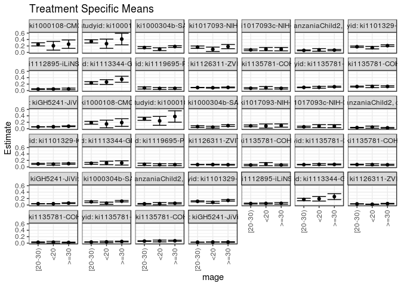

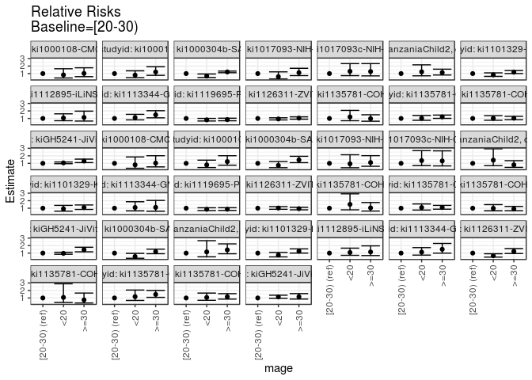

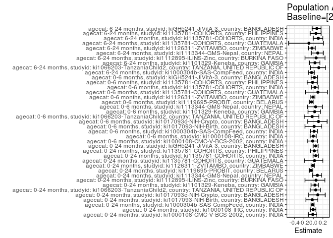

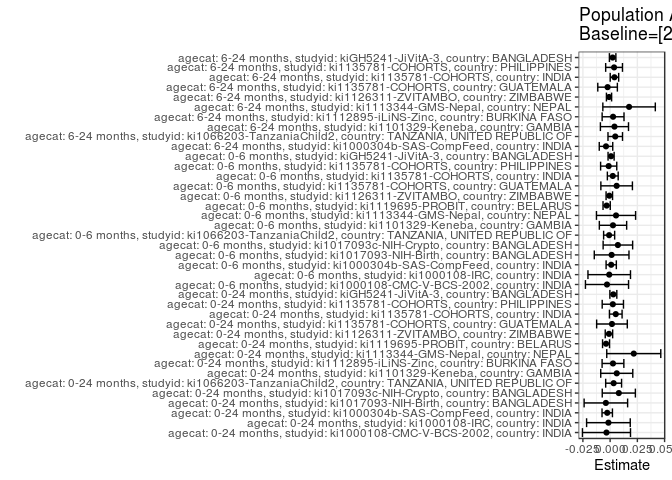

## Results Table

### Parameter: TSM

| agecat | studyid | country | intervention_level | baseline_level | estimate | ci_lower | ci_upper |
| --- | --- | --- | --- | --- | --- | --- | --- |
| 0-24 months | ki1000108-CMC-V-BCS-2002 | INDIA | [20-30) | NA | 0.2500000 | 0.2006047 | 0.2993953 |
| 0-24 months | ki1000108-CMC-V-BCS-2002 | INDIA | <20 | NA | 0.2058824 | 0.0697869 | 0.3419778 |
| 0-24 months | ki1000108-CMC-V-BCS-2002 | INDIA | >=30 | NA | 0.2558140 | 0.1252270 | 0.3864009 |
| 0-24 months | ki1000108-IRC | INDIA | [20-30) | NA | 0.3430233 | 0.2927964 | 0.3932501 |
| 0-24 months | ki1000108-IRC | INDIA | <20 | NA | 0.2702703 | 0.1269995 | 0.4135411 |
| 0-24 months | ki1000108-IRC | INDIA | >=30 | NA | 0.4137931 | 0.2343212 | 0.5932650 |
| 0-24 months | ki1000304b-SAS-CompFeed | INDIA | [20-30) | NA | 0.1500431 | 0.1201652 | 0.1799210 |
| 0-24 months | ki1000304b-SAS-CompFeed | INDIA | <20 | NA | 0.1002234 | 0.0567526 | 0.1436943 |
| 0-24 months | ki1000304b-SAS-CompFeed | INDIA | >=30 | NA | 0.1825615 | 0.1559358 | 0.2091872 |
| 0-24 months | ki1017093-NIH-Birth | BANGLADESH | [20-30) | NA | 0.1630695 | 0.1275833 | 0.1985558 |
| 0-24 months | ki1017093-NIH-Birth | BANGLADESH | <20 | NA | 0.0958904 | 0.0282924 | 0.1634885 |
| 0-24 months | ki1017093-NIH-Birth | BANGLADESH | >=30 | NA | 0.1818182 | 0.1159684 | 0.2476679 |
| 0-24 months | ki1017093c-NIH-Crypto | BANGLADESH | [20-30) | NA | 0.0790941 | 0.0552566 | 0.1029315 |
| 0-24 months | ki1017093c-NIH-Crypto | BANGLADESH | <20 | NA | 0.1026938 | 0.0514124 | 0.1539752 |
| 0-24 months | ki1017093c-NIH-Crypto | BANGLADESH | >=30 | NA | 0.1005246 | 0.0478359 | 0.1532134 |
| 0-24 months | ki1066203-TanzaniaChild2 | TANZANIA, UNITED REPUBLIC OF | [20-30) | NA | 0.0628572 | 0.0508397 | 0.0748748 |
| 0-24 months | ki1066203-TanzaniaChild2 | TANZANIA, UNITED REPUBLIC OF | <20 | NA | 0.0772893 | 0.0362827 | 0.1182959 |
| 0-24 months | ki1066203-TanzaniaChild2 | TANZANIA, UNITED REPUBLIC OF | >=30 | NA | 0.0710602 | 0.0510785 | 0.0910419 |
| 0-24 months | ki1101329-Keneba | GAMBIA | [20-30) | NA | 0.1761737 | 0.1559302 | 0.1964172 |
| 0-24 months | ki1101329-Keneba | GAMBIA | <20 | NA | 0.1460604 | 0.1089662 | 0.1831546 |
| 0-24 months | ki1101329-Keneba | GAMBIA | >=30 | NA | 0.2092240 | 0.1835849 | 0.2348631 |
| 0-24 months | ki1112895-iLiNS-Zinc | BURKINA FASO | [20-30) | NA | 0.0445688 | 0.0311754 | 0.0579623 |
| 0-24 months | ki1112895-iLiNS-Zinc | BURKINA FASO | <20 | NA | 0.0473529 | 0.0316963 | 0.0630094 |
| 0-24 months | ki1112895-iLiNS-Zinc | BURKINA FASO | >=30 | NA | 0.0505796 | 0.0254299 | 0.0757293 |
| 0-24 months | ki1113344-GMS-Nepal | NEPAL | [20-30) | NA | 0.2363163 | 0.1967278 | 0.2759047 |
| 0-24 months | ki1113344-GMS-Nepal | NEPAL | <20 | NA | 0.2642157 | 0.1904665 | 0.3379649 |
| 0-24 months | ki1113344-GMS-Nepal | NEPAL | >=30 | NA | 0.3503655 | 0.2566644 | 0.4440667 |
| 0-24 months | ki1119695-PROBIT | BELARUS | [20-30) | NA | 0.0812121 | 0.0470259 | 0.1153983 |
| 0-24 months | ki1119695-PROBIT | BELARUS | <20 | NA | 0.0662358 | 0.0351748 | 0.0972968 |
| 0-24 months | ki1119695-PROBIT | BELARUS | >=30 | NA | 0.0687301 | 0.0398492 | 0.0976110 |

[output cut: 87 more lines]

### Parameter: E(Y)

| agecat | studyid | country | intervention_level | baseline_level | estimate | ci_lower | ci_upper |
| --- | --- | --- | --- | --- | --- | --- | --- |
| 0-24 months | ki1000108-CMC-V-BCS-2002 | INDIA | NA | NA | 0.2466488 | 0.2028447 | 0.2904529 |
| 0-24 months | ki1000108-IRC | INDIA | NA | NA | 0.3414634 | 0.2955068 | 0.3874201 |
| 0-24 months | ki1000304b-SAS-CompFeed | INDIA | NA | NA | 0.1473893 | 0.1184132 | 0.1763654 |
| 0-24 months | ki1017093-NIH-Birth | BANGLADESH | NA | NA | 0.1591640 | 0.1303913 | 0.1879367 |
| 0-24 months | ki1017093c-NIH-Crypto | BANGLADESH | NA | NA | 0.0870712 | 0.0669870 | 0.1071555 |
| 0-24 months | ki1066203-TanzaniaChild2 | TANZANIA, UNITED REPUBLIC OF | NA | NA | 0.0660774 | 0.0560867 | 0.0760682 |
| 0-24 months | ki1101329-Keneba | GAMBIA | NA | NA | 0.1822626 | 0.1681211 | 0.1964040 |
| 0-24 months | ki1112895-iLiNS-Zinc | BURKINA FASO | NA | NA | 0.0471847 | 0.0353428 | 0.0590265 |
| 0-24 months | ki1113344-GMS-Nepal | NEPAL | NA | NA | 0.2580175 | 0.2252514 | 0.2907836 |
| 0-24 months | ki1119695-PROBIT | BELARUS | NA | NA | 0.0774648 | 0.0450418 | 0.1098878 |
| 0-24 months | ki1126311-ZVITAMBO | ZIMBABWE | NA | NA | 0.0919615 | 0.0871588 | 0.0967642 |
| 0-24 months | ki1135781-COHORTS | GUATEMALA | NA | NA | 0.0723341 | 0.0584645 | 0.0862036 |
| 0-24 months | ki1135781-COHORTS | INDIA | NA | NA | 0.1031103 | 0.0949263 | 0.1112943 |
| 0-24 months | ki1135781-COHORTS | PHILIPPINES | NA | NA | 0.1254516 | 0.1136848 | 0.1372183 |
| 0-24 months | kiGH5241-JiVitA-3 | BANGLADESH | NA | NA | 0.0610132 | 0.0575333 | 0.0644930 |
| 0-6 months | ki1000108-CMC-V-BCS-2002 | INDIA | NA | NA | 0.1820652 | 0.1425842 | 0.2215462 |
| 0-6 months | ki1000108-IRC | INDIA | NA | NA | 0.3073171 | 0.2626027 | 0.3520314 |
| 0-6 months | ki1000304b-SAS-CompFeed | INDIA | NA | NA | 0.0664452 | 0.0425975 | 0.0902929 |
| 0-6 months | ki1017093-NIH-Birth | BANGLADESH | NA | NA | 0.0903226 | 0.0677415 | 0.1129037 |
| 0-6 months | ki1017093c-NIH-Crypto | BANGLADESH | NA | NA | 0.0659631 | 0.0482810 | 0.0836451 |
| 0-6 months | ki1066203-TanzaniaChild2 | TANZANIA, UNITED REPUBLIC OF | NA | NA | 0.0328283 | 0.0256620 | 0.0399945 |
| 0-6 months | ki1101329-Keneba | GAMBIA | NA | NA | 0.0945172 | 0.0829165 | 0.1061178 |
| 0-6 months | ki1113344-GMS-Nepal | NEPAL | NA | NA | 0.1151604 | 0.0912555 | 0.1390652 |
| 0-6 months | ki1119695-PROBIT | BELARUS | NA | NA | 0.0760580 | 0.0435003 | 0.1086157 |
| 0-6 months | ki1126311-ZVITAMBO | ZIMBABWE | NA | NA | 0.0685487 | 0.0643349 | 0.0727624 |
| 0-6 months | ki1135781-COHORTS | GUATEMALA | NA | NA | 0.0630292 | 0.0484135 | 0.0776449 |
| 0-6 months | ki1135781-COHORTS | INDIA | NA | NA | 0.0713446 | 0.0642809 | 0.0784082 |
| 0-6 months | ki1135781-COHORTS | PHILIPPINES | NA | NA | 0.0693167 | 0.0602923 | 0.0783411 |
| 0-6 months | kiGH5241-JiVitA-3 | BANGLADESH | NA | NA | 0.0413811 | 0.0384001 | 0.0443621 |
| 6-24 months | ki1000304b-SAS-CompFeed | INDIA | NA | NA | 0.0964723 | 0.0729872 | 0.1199573 |
| 6-24 months | ki1066203-TanzaniaChild2 | TANZANIA, UNITED REPUBLIC OF | NA | NA | 0.0414378 | 0.0327076 | 0.0501681 |
| 6-24 months | ki1101329-Keneba | GAMBIA | NA | NA | 0.1178877 | 0.1056970 | 0.1300784 |
| 6-24 months | ki1112895-iLiNS-Zinc | BURKINA FASO | NA | NA | 0.0471847 | 0.0353428 | 0.0590265 |
| 6-24 months | ki1113344-GMS-Nepal | NEPAL | NA | NA | 0.1898305 | 0.1581595 | 0.2215015 |
| 6-24 months | ki1126311-ZVITAMBO | ZIMBABWE | NA | NA | 0.0329039 | 0.0295377 | 0.0362701 |
| 6-24 months | ki1135781-COHORTS | GUATEMALA | NA | NA | 0.0247321 | 0.0159885 | 0.0334756 |
| 6-24 months | ki1135781-COHORTS | INDIA | NA | NA | 0.0381279 | 0.0327962 | 0.0434596 |
| 6-24 months | ki1135781-COHORTS | PHILIPPINES | NA | NA | 0.0669277 | 0.0576848 | 0.0761707 |
| 6-24 months | kiGH5241-JiVitA-3 | BANGLADESH | NA | NA | 0.0319223 | 0.0290352 | 0.0348093 |

### Parameter: RR

| agecat | studyid | country | intervention_level | baseline_level | estimate | ci_lower | ci_upper |
| --- | --- | --- | --- | --- | --- | --- | --- |
| 0-24 months | ki1000108-CMC-V-BCS-2002 | INDIA | [20-30) | [20-30) | 1.0000000 | 1.0000000 | 1.0000000 |
| 0-24 months | ki1000108-CMC-V-BCS-2002 | INDIA | <20 | [20-30) | 0.8235294 | 0.4130909 | 1.6417711 |
| 0-24 months | ki1000108-CMC-V-BCS-2002 | INDIA | >=30 | [20-30) | 1.0232558 | 0.5919164 | 1.7689196 |
| 0-24 months | ki1000108-IRC | INDIA | [20-30) | [20-30) | 1.0000000 | 1.0000000 | 1.0000000 |
| 0-24 months | ki1000108-IRC | INDIA | <20 | [20-30) | 0.7879066 | 0.4546040 | 1.3655769 |
| 0-24 months | ki1000108-IRC | INDIA | >=30 | [20-30) | 1.2063121 | 0.7632228 | 1.9066372 |
| 0-24 months | ki1000304b-SAS-CompFeed | INDIA | [20-30) | [20-30) | 1.0000000 | 1.0000000 | 1.0000000 |
| 0-24 months | ki1000304b-SAS-CompFeed | INDIA | <20 | [20-30) | 0.6679644 | 0.4724568 | 0.9443751 |
| 0-24 months | ki1000304b-SAS-CompFeed | INDIA | >=30 | [20-30) | 1.2167268 | 1.1148178 | 1.3279517 |
| 0-24 months | ki1017093-NIH-Birth | BANGLADESH | [20-30) | [20-30) | 1.0000000 | 1.0000000 | 1.0000000 |
| 0-24 months | ki1017093-NIH-Birth | BANGLADESH | <20 | [20-30) | 0.5880339 | 0.2811841 | 1.2297419 |
| 0-24 months | ki1017093-NIH-Birth | BANGLADESH | >=30 | [20-30) | 1.1149733 | 0.7307436 | 1.7012334 |
| 0-24 months | ki1017093c-NIH-Crypto | BANGLADESH | [20-30) | [20-30) | 1.0000000 | 1.0000000 | 1.0000000 |
| 0-24 months | ki1017093c-NIH-Crypto | BANGLADESH | <20 | [20-30) | 1.2983755 | 0.7249340 | 2.3254240 |
| 0-24 months | ki1017093c-NIH-Crypto | BANGLADESH | >=30 | [20-30) | 1.2709502 | 0.6943839 | 2.3262555 |
| 0-24 months | ki1066203-TanzaniaChild2 | TANZANIA, UNITED REPUBLIC OF | [20-30) | [20-30) | 1.0000000 | 1.0000000 | 1.0000000 |
| 0-24 months | ki1066203-TanzaniaChild2 | TANZANIA, UNITED REPUBLIC OF | <20 | [20-30) | 1.2296007 | 0.6995738 | 2.1611986 |
| 0-24 months | ki1066203-TanzaniaChild2 | TANZANIA, UNITED REPUBLIC OF | >=30 | [20-30) | 1.1305020 | 0.8046658 | 1.5882801 |
| 0-24 months | ki1101329-Keneba | GAMBIA | [20-30) | [20-30) | 1.0000000 | 1.0000000 | 1.0000000 |
| 0-24 months | ki1101329-Keneba | GAMBIA | <20 | [20-30) | 0.8290706 | 0.6274922 | 1.0954051 |
| 0-24 months | ki1101329-Keneba | GAMBIA | >=30 | [20-30) | 1.1876008 | 1.0039954 | 1.4047829 |
| 0-24 months | ki1112895-iLiNS-Zinc | BURKINA FASO | [20-30) | [20-30) | 1.0000000 | 1.0000000 | 1.0000000 |
| 0-24 months | ki1112895-iLiNS-Zinc | BURKINA FASO | <20 | [20-30) | 1.0624657 | 0.6974487 | 1.6185183 |
| 0-24 months | ki1112895-iLiNS-Zinc | BURKINA FASO | >=30 | [20-30) | 1.1348651 | 0.6528654 | 1.9727172 |
| 0-24 months | ki1113344-GMS-Nepal | NEPAL | [20-30) | [20-30) | 1.0000000 | 1.0000000 | 1.0000000 |
| 0-24 months | ki1113344-GMS-Nepal | NEPAL | <20 | [20-30) | 1.1180598 | 0.8071731 | 1.5486861 |
| 0-24 months | ki1113344-GMS-Nepal | NEPAL | >=30 | [20-30) | 1.4826130 | 1.0812406 | 2.0329808 |
| 0-24 months | ki1119695-PROBIT | BELARUS | [20-30) | [20-30) | 1.0000000 | 1.0000000 | 1.0000000 |
| 0-24 months | ki1119695-PROBIT | BELARUS | <20 | [20-30) | 0.8155902 | 0.6622596 | 1.0044208 |
| 0-24 months | ki1119695-PROBIT | BELARUS | >=30 | [20-30) | 0.8463042 | 0.6919715 | 1.0350583 |

[output cut: 87 more lines]

### Parameter: PAR

| agecat | studyid | country | intervention_level | baseline_level | estimate | ci_lower | ci_upper |
| --- | --- | --- | --- | --- | --- | --- | --- |
| 0-24 months | ki1000108-CMC-V-BCS-2002 | INDIA | [20-30) | NA | -0.0033512 | -0.0254025 | 0.0187001 |
| 0-24 months | ki1000108-IRC | INDIA | [20-30) | NA | -0.0015598 | -0.0215967 | 0.0184770 |
| 0-24 months | ki1000304b-SAS-CompFeed | INDIA | [20-30) | NA | -0.0026538 | -0.0074350 | 0.0021274 |
| 0-24 months | ki1017093-NIH-Birth | BANGLADESH | [20-30) | NA | -0.0039056 | -0.0238720 | 0.0160609 |
| 0-24 months | ki1017093c-NIH-Crypto | BANGLADESH | [20-30) | NA | 0.0079772 | -0.0072350 | 0.0231893 |
| 0-24 months | ki1066203-TanzaniaChild2 | TANZANIA, UNITED REPUBLIC OF | [20-30) | NA | 0.0032202 | -0.0040777 | 0.0105182 |
| 0-24 months | ki1101329-Keneba | GAMBIA | [20-30) | NA | 0.0060889 | -0.0086206 | 0.0207984 |
| 0-24 months | ki1112895-iLiNS-Zinc | BURKINA FASO | [20-30) | NA | 0.0026158 | -0.0073651 | 0.0125967 |
| 0-24 months | ki1113344-GMS-Nepal | NEPAL | [20-30) | NA | 0.0217012 | -0.0031000 | 0.0465025 |
| 0-24 months | ki1119695-PROBIT | BELARUS | [20-30) | NA | -0.0037473 | -0.0069488 | -0.0005458 |
| 0-24 months | ki1126311-ZVITAMBO | ZIMBABWE | [20-30) | NA | -0.0010747 | -0.0044822 | 0.0023328 |
| 0-24 months | ki1135781-COHORTS | GUATEMALA | [20-30) | NA | 0.0016960 | -0.0123763 | 0.0157684 |
| 0-24 months | ki1135781-COHORTS | INDIA | [20-30) | NA | 0.0051754 | -0.0006273 | 0.0109781 |
| 0-24 months | ki1135781-COHORTS | PHILIPPINES | [20-30) | NA | 0.0024889 | -0.0072806 | 0.0122584 |
| 0-24 months | kiGH5241-JiVitA-3 | BANGLADESH | [20-30) | NA | 0.0029569 | -0.0002305 | 0.0061442 |
| 0-6 months | ki1000108-CMC-V-BCS-2002 | INDIA | [20-30) | NA | -0.0028663 | -0.0226565 | 0.0169239 |
| 0-6 months | ki1000108-IRC | INDIA | [20-30) | NA | -0.0008225 | -0.0203468 | 0.0187019 |
| 0-6 months | ki1000304b-SAS-CompFeed | INDIA | [20-30) | NA | 0.0010002 | -0.0036966 | 0.0056969 |
| 0-6 months | ki1017093-NIH-Birth | BANGLADESH | [20-30) | NA | 0.0013803 | -0.0145456 | 0.0173061 |
| 0-6 months | ki1017093c-NIH-Crypto | BANGLADESH | [20-30) | NA | 0.0071270 | -0.0064153 | 0.0206692 |
| 0-6 months | ki1066203-TanzaniaChild2 | TANZANIA, UNITED REPUBLIC OF | [20-30) | NA | -0.0009082 | -0.0059724 | 0.0041560 |
| 0-6 months | ki1101329-Keneba | GAMBIA | [20-30) | NA | 0.0026343 | -0.0099065 | 0.0151750 |
| 0-6 months | ki1113344-GMS-Nepal | NEPAL | [20-30) | NA | 0.0054246 | -0.0125372 | 0.0233864 |
| 0-6 months | ki1119695-PROBIT | BELARUS | [20-30) | NA | -0.0031928 | -0.0065141 | 0.0001285 |
| 0-6 months | ki1126311-ZVITAMBO | ZIMBABWE | [20-30) | NA | -0.0007366 | -0.0037105 | 0.0022373 |
| 0-6 months | ki1135781-COHORTS | GUATEMALA | [20-30) | NA | 0.0059858 | -0.0084995 | 0.0204712 |
| 0-6 months | ki1135781-COHORTS | INDIA | [20-30) | NA | 0.0024334 | -0.0025313 | 0.0073982 |
| 0-6 months | ki1135781-COHORTS | PHILIPPINES | [20-30) | NA | -0.0013205 | -0.0087343 | 0.0060933 |
| 0-6 months | kiGH5241-JiVitA-3 | BANGLADESH | [20-30) | NA | 0.0008888 | -0.0018977 | 0.0036752 |
| 6-24 months | ki1000304b-SAS-CompFeed | INDIA | [20-30) | NA | -0.0037835 | -0.0099705 | 0.0024036 |
| 6-24 months | ki1066203-TanzaniaChild2 | TANZANIA, UNITED REPUBLIC OF | [20-30) | NA | 0.0047125 | -0.0019571 | 0.0113821 |
| 6-24 months | ki1101329-Keneba | GAMBIA | [20-30) | NA | 0.0039759 | -0.0089199 | 0.0168718 |
| 6-24 months | ki1112895-iLiNS-Zinc | BURKINA FASO | [20-30) | NA | 0.0027045 | -0.0073308 | 0.0127399 |
| 6-24 months | ki1113344-GMS-Nepal | NEPAL | [20-30) | NA | 0.0174007 | -0.0066845 | 0.0414859 |
| 6-24 months | ki1126311-ZVITAMBO | ZIMBABWE | [20-30) | NA | -0.0010108 | -0.0033893 | 0.0013677 |
| 6-24 months | ki1135781-COHORTS | GUATEMALA | [20-30) | NA | -0.0023407 | -0.0113312 | 0.0066498 |
| 6-24 months | ki1135781-COHORTS | INDIA | [20-30) | NA | 0.0039691 | 0.0000841 | 0.0078542 |
| 6-24 months | ki1135781-COHORTS | PHILIPPINES | [20-30) | NA | 0.0036325 | -0.0040836 | 0.0113486 |
| 6-24 months | kiGH5241-JiVitA-3 | BANGLADESH | [20-30) | NA | 0.0023067 | -0.0006684 | 0.0052818 |

### Parameter: PAF

| agecat | studyid | country | intervention_level | baseline_level | estimate | ci_lower | ci_upper |
| --- | --- | --- | --- | --- | --- | --- | --- |
| 0-24 months | ki1000108-CMC-V-BCS-2002 | INDIA | [20-30) | NA | -0.0135870 | -0.1070401 | 0.0719771 |
| 0-24 months | ki1000108-IRC | INDIA | [20-30) | NA | -0.0045681 | -0.0649954 | 0.0524305 |
| 0-24 months | ki1000304b-SAS-CompFeed | INDIA | [20-30) | NA | -0.0180054 | -0.0507677 | 0.0137353 |
| 0-24 months | ki1017093-NIH-Birth | BANGLADESH | [20-30) | NA | -0.0245379 | -0.1579328 | 0.0934897 |
| 0-24 months | ki1017093c-NIH-Crypto | BANGLADESH | [20-30) | NA | 0.0916165 | -0.0997809 | 0.2497046 |
| 0-24 months | ki1066203-TanzaniaChild2 | TANZANIA, UNITED REPUBLIC OF | [20-30) | NA | 0.0487341 | -0.0681632 | 0.1528385 |
| 0-24 months | ki1101329-Keneba | GAMBIA | [20-30) | NA | 0.0334073 | -0.0507638 | 0.1108359 |
| 0-24 months | ki1112895-iLiNS-Zinc | BURKINA FASO | [20-30) | NA | 0.0554377 | -0.1777449 | 0.2424523 |
| 0-24 months | ki1113344-GMS-Nepal | NEPAL | [20-30) | NA | 0.0841076 | -0.0170123 | 0.1751734 |
| 0-24 months | ki1119695-PROBIT | BELARUS | [20-30) | NA | -0.0483743 | -0.0843884 | -0.0135563 |
| 0-24 months | ki1126311-ZVITAMBO | ZIMBABWE | [20-30) | NA | -0.0116866 | -0.0494168 | 0.0246871 |
| 0-24 months | ki1135781-COHORTS | GUATEMALA | [20-30) | NA | 0.0234474 | -0.1917856 | 0.1998100 |
| 0-24 months | ki1135781-COHORTS | INDIA | [20-30) | NA | 0.0501929 | -0.0076692 | 0.1047326 |
| 0-24 months | ki1135781-COHORTS | PHILIPPINES | [20-30) | NA | 0.0198394 | -0.0611976 | 0.0946880 |
| 0-24 months | kiGH5241-JiVitA-3 | BANGLADESH | [20-30) | NA | 0.0484631 | -0.0052039 | 0.0992649 |
| 0-6 months | ki1000108-CMC-V-BCS-2002 | INDIA | [20-30) | NA | -0.0157432 | -0.1304383 | 0.0873149 |
| 0-6 months | ki1000108-IRC | INDIA | [20-30) | NA | -0.0026763 | -0.0682637 | 0.0588843 |
| 0-6 months | ki1000304b-SAS-CompFeed | INDIA | [20-30) | NA | 0.0150524 | -0.0603904 | 0.0851277 |
| 0-6 months | ki1017093-NIH-Birth | BANGLADESH | [20-30) | NA | 0.0152816 | -0.1777722 | 0.1766911 |
| 0-6 months | ki1017093c-NIH-Crypto | BANGLADESH | [20-30) | NA | 0.1080448 | -0.1204747 | 0.2899580 |
| 0-6 months | ki1066203-TanzaniaChild2 | TANZANIA, UNITED REPUBLIC OF | [20-30) | NA | -0.0276649 | -0.1939816 | 0.1154846 |
| 0-6 months | ki1101329-Keneba | GAMBIA | [20-30) | NA | 0.0278707 | -0.1142940 | 0.1518976 |
| 0-6 months | ki1113344-GMS-Nepal | NEPAL | [20-30) | NA | 0.0471045 | -0.1221699 | 0.1908446 |
| 0-6 months | ki1119695-PROBIT | BELARUS | [20-30) | NA | -0.0419781 | -0.0798244 | -0.0054582 |
| 0-6 months | ki1126311-ZVITAMBO | ZIMBABWE | [20-30) | NA | -0.0107454 | -0.0550656 | 0.0317130 |
| 0-6 months | ki1135781-COHORTS | GUATEMALA | [20-30) | NA | 0.0949695 | -0.1654061 | 0.2971718 |
| 0-6 months | ki1135781-COHORTS | INDIA | [20-30) | NA | 0.0341083 | -0.0379789 | 0.1011890 |
| 0-6 months | ki1135781-COHORTS | PHILIPPINES | [20-30) | NA | -0.0190506 | -0.1317886 | 0.0824575 |
| 0-6 months | kiGH5241-JiVitA-3 | BANGLADESH | [20-30) | NA | 0.0214777 | -0.0482402 | 0.0865586 |
| 6-24 months | ki1000304b-SAS-CompFeed | INDIA | [20-30) | NA | -0.0392182 | -0.1003608 | 0.0185270 |
| 6-24 months | ki1066203-TanzaniaChild2 | TANZANIA, UNITED REPUBLIC OF | [20-30) | NA | 0.1137250 | -0.0607877 | 0.2595282 |
| 6-24 months | ki1101329-Keneba | GAMBIA | [20-30) | NA | 0.0337265 | -0.0820976 | 0.1371532 |
| 6-24 months | ki1112895-iLiNS-Zinc | BURKINA FASO | [20-30) | NA | 0.0573180 | -0.1773203 | 0.2451932 |
| 6-24 months | ki1113344-GMS-Nepal | NEPAL | [20-30) | NA | 0.0916644 | -0.0439554 | 0.2096659 |
| 6-24 months | ki1126311-ZVITAMBO | ZIMBABWE | [20-30) | NA | -0.0307204 | -0.1054787 | 0.0389823 |
| 6-24 months | ki1135781-COHORTS | GUATEMALA | [20-30) | NA | -0.0946418 | -0.5237626 | 0.2136303 |
| 6-24 months | ki1135781-COHORTS | INDIA | [20-30) | NA | 0.1041008 | -0.0027597 | 0.1995736 |
| 6-24 months | ki1135781-COHORTS | PHILIPPINES | [20-30) | NA | 0.0542750 | -0.0681033 | 0.1626318 |
| 6-24 months | kiGH5241-JiVitA-3 | BANGLADESH | [20-30) | NA | 0.0722593 | -0.0255493 | 0.1607398 |